# 3-Bathymetry

## 3-Bathymetry

A quick look at plotting data points on to a bathymetric map. We are going to use Adrian’s collection data and an open source bathymetry map.

## Data Manipulation

As part of the tidyverse, dplyr provides a fast way to alter data. It works around “verbs” https://dplyr.tidyverse.org/. I’ll use these dplyr verbs and a pipe, %>%, to summarize Adrian’s collection information.

First off I’ll read in the data and then covert to a tibble. To do so I first converted the original .xlsx to a .csv. Reading in an .xlsx is certainly possible, but more complicated.

A tibble makes it easier for us to view. It limits the output in terms of length and number of digits, etc. Importantly, it tells us what is in each column, i.e. numbers or characters or factors.

```r
library(tidyverse)
library(ggrepel)

data<-as_tibble(read.csv(file="Chelidoperca_geodata.csv"))

data
```

```
## # A tibble: 47 x 6
##    Species.name   Specimen.No. Latitude Longitude depth..m. Mean.depth..m.
##    <fct>          <fct>           <dbl>     <dbl> <fct>              <dbl>
##  1 C. leucostigm… WJC5681         -2.57      151. 147-151             149
##  2 C. leucostigm… WJC5843         16.1       114. 162-165             164.
##  3 C. leucostigm… WJC5844         16.1       114. 162-165             164.
##  4 C. leucostigm… WJC5845         16.1       114. 162-165             164.
##  5 C. leucostigm… WJC5910         16.1       114. 162-163             162.
##  6 C. leucostigm… WJC5911         16.1       114. 162-163             162.
##  7 C. pleurospil… WJC6159         20.8       117. 190-221             206.
##  8 C. pleurospil… WJC6160         20.8       117. 190-221             206.
##  9 C. pleurospil… PNG1690         -2.52      151. 218-234             226
## 10 C. pleurospil… PNG1691         -2.52      151. 218-234             226
## # ... with 37 more rows
```

These data have several columns that dplyr can act on. We’ll send the data along to different verbs with %>%. Let’s look at how the data are organized a bit more.

There are multiple species entries for the same locations and about the same depth. We can use dplyr functions to reshape the data.

One thing I would like is to rename the columns.

```r
df1<-data %>% rename(Species=Species.name, MeanDepth=Mean.depth..m.)

df1
```

```
## # A tibble: 47 x 6
##    Species             Specimen.No. Latitude Longitude depth..m. MeanDepth
##    <fct>               <fct>           <dbl>     <dbl> <fct>         <dbl>
##  1 C. leucostigmata n… WJC5681         -2.57      151. 147-151        149
##  2 C. leucostigmata n… WJC5843         16.1       114. 162-165        164.
##  3 C. leucostigmata n… WJC5844         16.1       114. 162-165        164.
##  4 C. leucostigmata n… WJC5845         16.1       114. 162-165        164.
##  5 C. leucostigmata n… WJC5910         16.1       114. 162-163        162.
##  6 C. leucostigmata n… WJC5911         16.1       114. 162-163        162.
##  7 C. pleurospilus     WJC6159         20.8       117. 190-221        206.
##  8 C. pleurospilus     WJC6160         20.8       117. 190-221        206.
##  9 C. pleurospilus     PNG1690         -2.52      151. 218-234        226
## 10 C. pleurospilus     PNG1691         -2.52      151. 218-234        226
## # ... with 37 more rows
```

The object data was sent to the rename function and the output stored as df1.

I would like the data in terms of how many collections/site at a certain mean depth.

- group_by groups by column name, those entries that share the same Species, Latitude, Longitude, and Mean Depth are put together.
- count() gives us the number in the group in a new column “n”
- rename changes n to N.

```r
df2<-df1 %>% group_by(Species, Latitude, Longitude, MeanDepth) %>%
  count() %>%
  rename(N=n)

df2
```

```
## # A tibble: 22 x 5
## # Groups:   Species, Latitude, Longitude, MeanDepth [22]
##    Species                 Latitude Longitude MeanDepth     N
##    <fct>                      <dbl>     <dbl>     <dbl> <int>
##  1 C. aurantimaculata nsp.   -25.1       160.      295      1
##  2 C. aurantimaculata nsp.   -24.2       160.      295      1
##  3 C. aurantimaculata nsp.   -23.2       160.      280      2
##  4 C. aurantimaculata nsp.   -22.3       169.      338      1
##  5 C. lecromi                -22.8       167.      264.     1
##  6 C. lecromi                -19.8       158.      280      6
##  7 C. leucostigmata nsp.      -2.57      151.      149      1
##  8 C. leucostigmata nsp.      16.1       114.      164.     3
##  9 C. leucostigmata nsp.      16.1       114.      162.     2
## 10 C. nsp.A.                 -22.7       167.      285      1
## # ... with 12 more rows
```

## Plotting Points

Now we can plot our points with ggplot! Can you make this plot with geom_point?

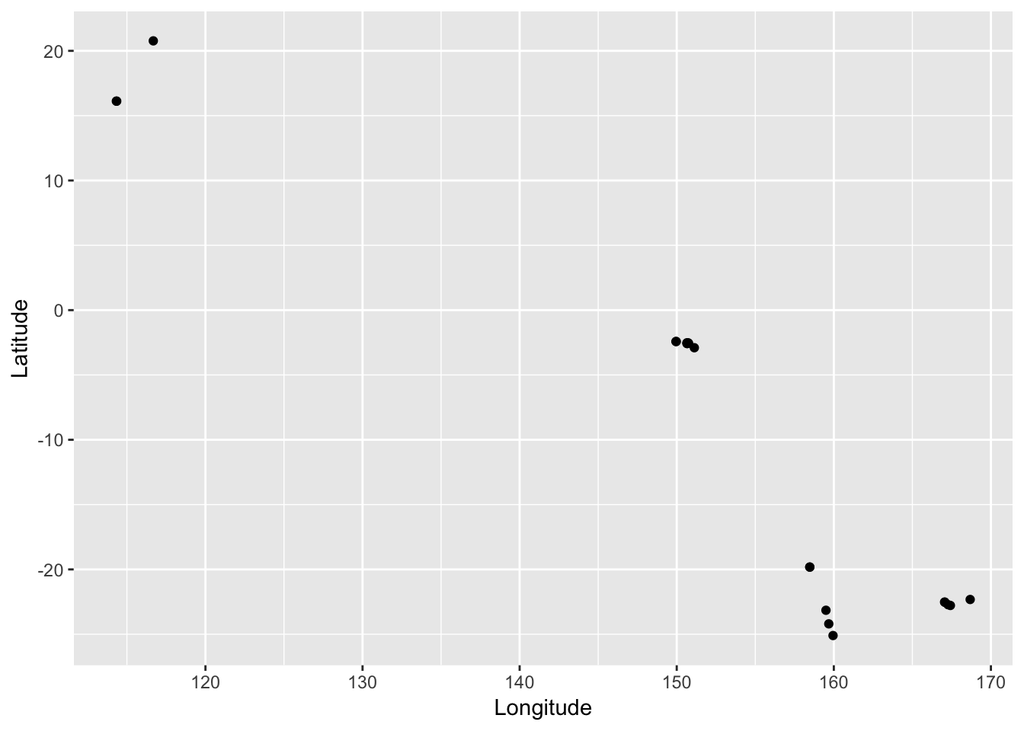

Two aesthetics controlled within aes() seem relevant to me. We can make the size proportional to the sample number. We can also use color to distinguish species?

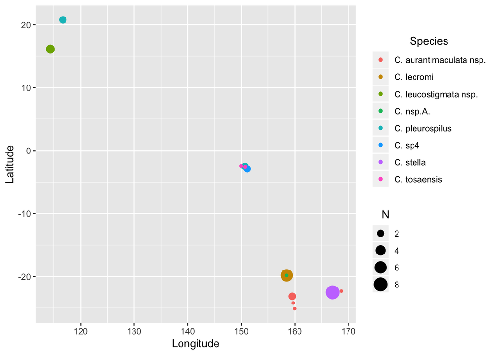

```r
ggplot()+geom_point(data=df2, aes(x=Longitude, y=Latitude,
                                  size=N, color=Species))+
  theme(legend.title.align = 0.5)
```

What should we do to make this plot better? I want to change the points to have a black outline which we can specify with shape=21. At this point, color is the outside of the point and fill the inside. Alpha lets us control opacity.

Like viridis, there is another color package for r, RColorBrewer. It has been made part of ggplot: https://ggplot2.tidyverse.org/reference/scale_brewer.html

Maybe this looks better?

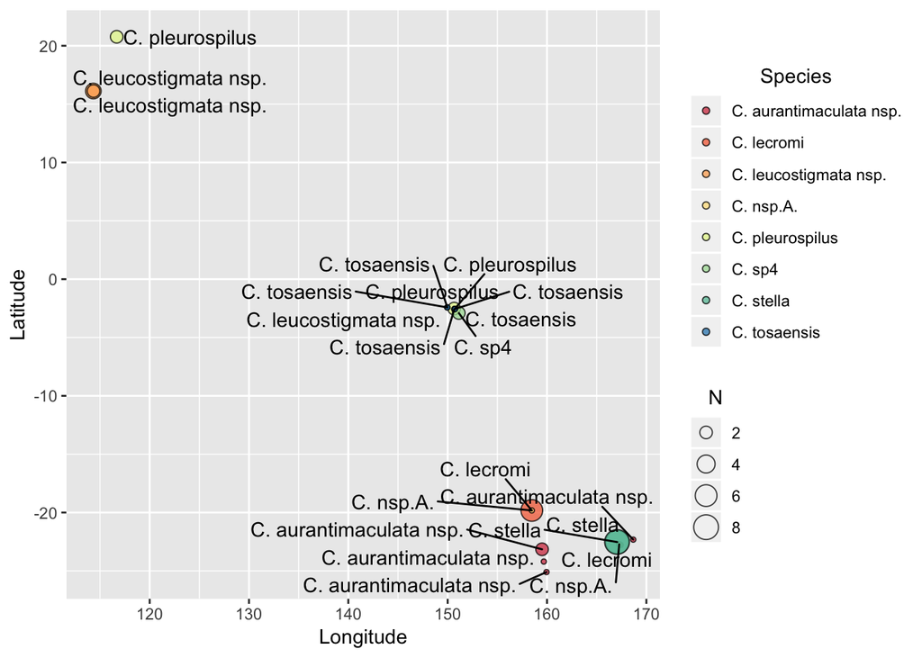

```r
ggplot()+geom_point(data=df2, aes(x=Longitude, y=Latitude,
                                  size=N, fill=Species), shape=21,
                    alpha=0.75)+
  geom_text_repel(data=df2, aes(x=Longitude, y=Latitude,
                                 label=Species))+
  theme(legend.title.align = 0.5)+
  scale_fill_brewer(type="div", palette = "Spectral")
```

Well, we have a lot of options, so what should we do?

Note: Aesthetics can be inherited.

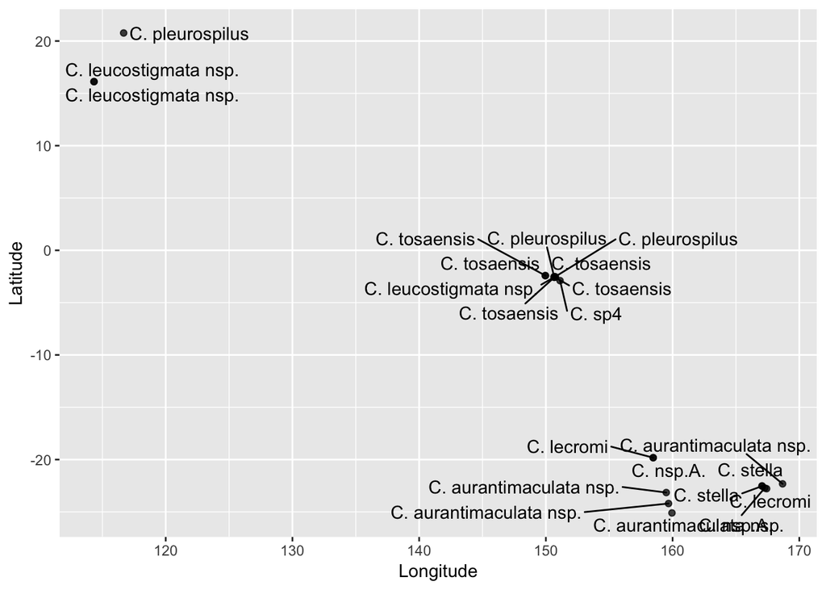

```r
ggplot(df2)+geom_point(aes(x=Longitude, y=Latitude), color="black",
                    alpha=0.75)+
  geom_text_repel(aes(x=Longitude, y=Latitude, label=Species))+
  theme(legend.title.align = 0.5)
```

## Facets

I think we should facet! This allows us to split our plots with the commands facet_wrap or facet_grid.

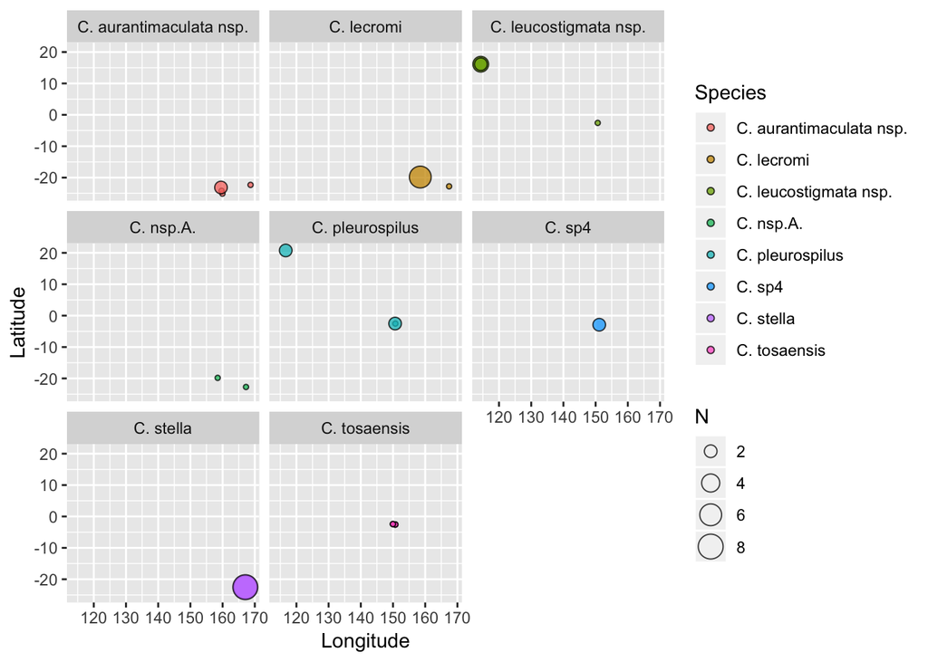

```r
ggplot()+geom_point(data=df2, aes(x=Longitude, y=Latitude,
                                  size=N, fill=Species), shape=21,
                    alpha=0.75)+
  facet_wrap(.~Species, nrow=3)
```

A few adjustments maybe make it nicer. In this way we see some species are distributed in the NW of the plots, some in the SE, and in the middle too. Rather than species, it seems to me the depth that the species are collected at is important. I’ve also stored this as an object called plot.

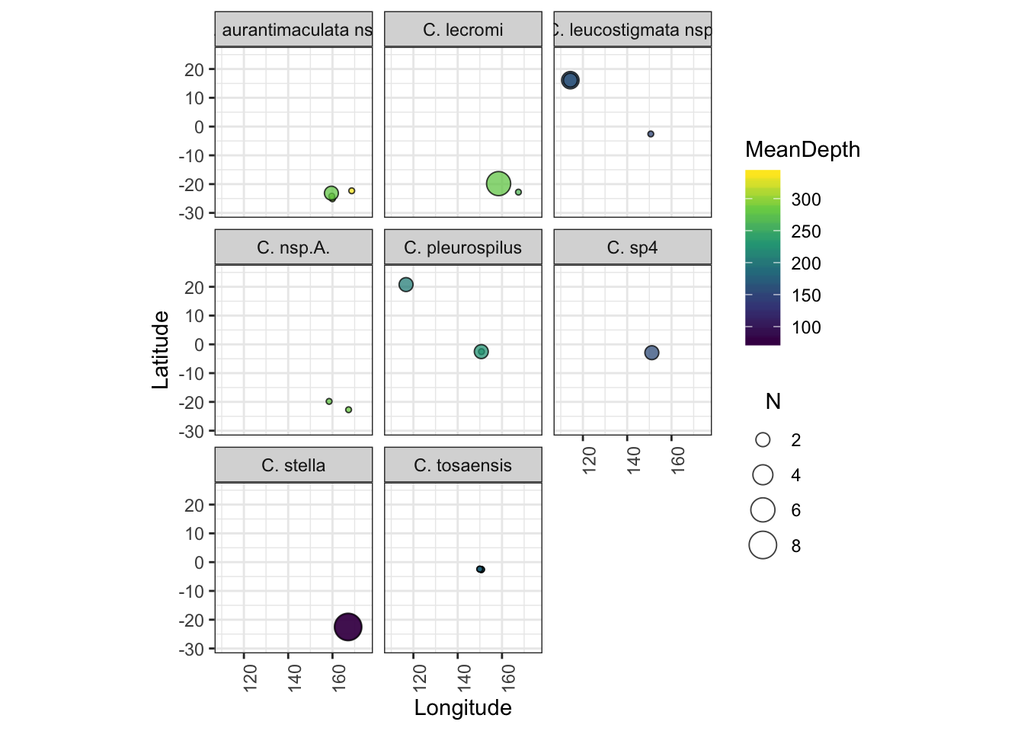

```r
plot<-ggplot()+geom_point(data=df2, aes(x=Longitude, y=Latitude,
                                  size=N, fill=MeanDepth), shape=21,
                    alpha=0.75)+
  theme_bw()+
  theme(legend.title.align = 0.5,
        axis.text.x = element_text(angle = 90, hjust = 1))+
  scale_fill_viridis_c()+
  coord_fixed(1.3, xlim = c(110, 175), ylim=c(-29,25) )+
  facet_wrap(.~Species, nrow=3)

plot
```

## What About Geography?

Clearly these species are not just hanging out in white space. There appear to be three locations where the species cluster and depth seems to matter.

### Basic Map

Can you include the basic world map onto the object “plot?”

I’ve included the following to remove gridlines:

theme(panel.grid.major = element_blank(), panel.grid.minor = element_blank())

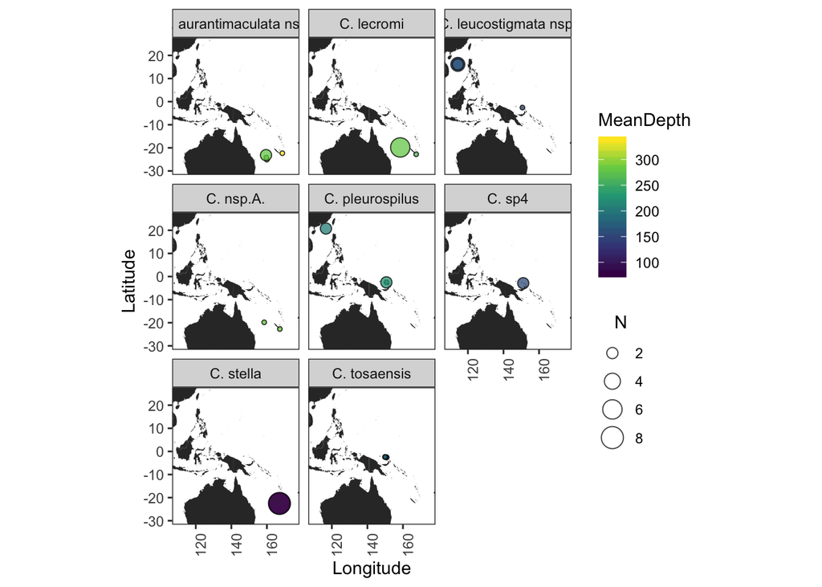

### Bathymetry

There are public bathymetry maps available. ETOPO1 is an option produced by NOAA (https://www.ngdc.noaa.gov/mgg/global/global.html).

We have two options here. We can download the raw ETOPO data ourselves, or, us an existing R library. Searching online I found “marmap”. This requires an internet connection so I have saved the resulting bathy object as file for you “bathy.rda” which took the following commands which you don’t need to do.

```r
# library(marmap)
# bathy<-getNOAA.bathy(lon1 = 100, lon2 = 180, lat1=-35, lat2=35, resolution=10)
# save("bathy", file="bathy.rda")
```

Now, to load the data and convert it to something useful. Marmap has a built in function “fortify.bathy()” to convert to a dataframe which is good for ggplot. This produces data that is compatible with geom_raster. Note the range of the z-axis: it includes elevation on land.

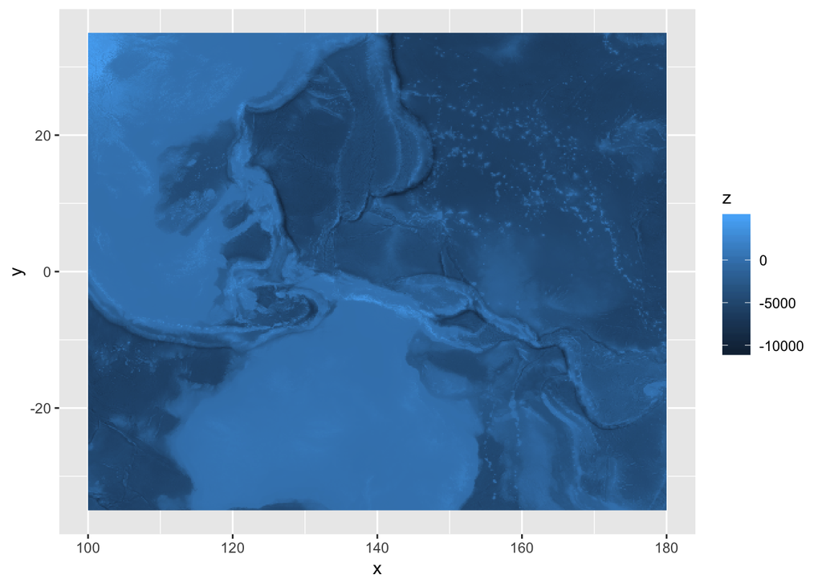

```r
library(marmap)
load(file="bathy.rda")
bathyDf<-fortify.bathy(bathy)

ggplot()+geom_raster(data=bathyDf, aes(x=x, y=y, fill=z))
```

I think we should filter out values in our bathymetry data frame > 0. Here is one way to do that by adding a new column “Depth” with ifelse.

ifelse(test, yes, no)

```r
summary(bathyDf$z)
```

```
##    Min. 1st Qu.  Median    Mean 3rd Qu.    Max.
##  -10725   -4866   -2926   -2614     -17    4972
```

```r
bathyDf2<-bathyDf %>% mutate(Depth = ifelse(z > 0, 0, z))

summary(bathyDf2$Depth)
```

```
##    Min. 1st Qu.  Median    Mean 3rd Qu.    Max.
##  -10725   -4866   -2926   -2712     -17       0
```

Ok, so let’s put that all together. ggplot plots in the order we specify. So we want to put our points on last or else they may be covered.

Other than that, I don’t know what looks good! It is really troublesome to produce more than one fill scale and we can try that another day.

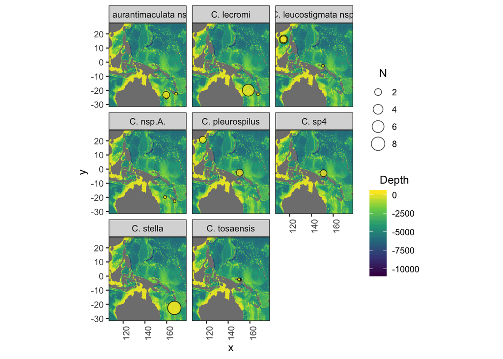

```r
ggplot()+geom_raster(data=bathyDf2, aes(x=x, y=y, fill=Depth))+
 geom_polygon(data=world, aes(x=long, y=lat, group=group),
              fill="grey50", color="grey50")+
  geom_point(data=df2, aes(x=Longitude, y=Latitude,
                                  size=N, fill=MeanDepth), shape=21,
                    alpha=0.75)+
  theme_bw()+
  theme(legend.title.align = 0.5,
        axis.text.x = element_text(angle = 90, hjust = 1))+
  theme(panel.grid.major = element_blank(), panel.grid.minor =  element_blank())+
  scale_fill_viridis_c()+
  coord_fixed(1.3, xlim = c(110, 175), ylim=c(-29,25) )+
  facet_wrap(.~Species, nrow=3)
```